# Heart Failure Analysis and Prediction

### About this dataset

###### Cardiovascular diseases (CVDs) are the number 1 cause of death globally, taking an estimated 17.9 million lives each year, which accounts for 31% of all deaths worlwide.Heart failure is a common event caused by CVDs and this dataset contains 12 features that can be used to predict mortality by heart failure.Most cardiovascular diseases can be prevented by addressing behavioural risk factors such as tobacco use, unhealthy diet and obesity, physical inactivity and harmful use of alcohol using population-wide strategies.People with cardiovascular disease or who are at high cardiovascular risk (due to the presence of one or more risk factors such as hypertension, diabetes, hyperlipidaemia or already established disease) need early detection and management wherein a machine learning model can be of great help.

### Importing libraries

```r
library(ggplot2)
library(dplyr);
library(rpart)
library(rpart.plot)
library(caret);
library(reshape2)
library(DataExplorer)
library(gridExtra)
```

### Impontring the data

#### We will import `heart_failure_clinical_records_dataset.csv`

```r
data <- read.csv("heart_failure_clinical_records_dataset.csv")
```

### First, let’s check nulls in the dataset

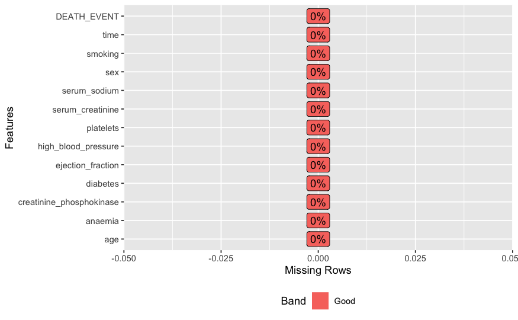

```r
plot_missing(data)
```

### Get a look at the dataset

```r
head(data, 10)
```

|  | age | anaemia | creatinine_phosphokinase | diabetes | ejection_fraction | high_blood_pressure | platelets | serum_creatinine | serum_sodium | sex | smoking | time | DEATH_EVENT |
| --- | --- | --- | --- | --- | --- | --- | --- | --- | --- | --- | --- | --- | --- |
| 1 | 75 | 0 | 582 | 0 | 20 | 1 | 265000 | 1.9 | 130 | 1 | 0 | 4 | 1 |
| 2 | 55 | 0 | 7861 | 0 | 38 | 0 | 263358 | 1.1 | 136 | 1 | 0 | 6 | 1 |
| 3 | 65 | 0 | 146 | 0 | 20 | 0 | 162000 | 1.3 | 129 | 1 | 1 | 7 | 1 |
| 4 | 50 | 1 | 111 | 0 | 20 | 0 | 210000 | 1.9 | 137 | 1 | 0 | 7 | 1 |
| 5 | 65 | 1 | 160 | 1 | 20 | 0 | 327000 | 2.7 | 116 | 0 | 0 | 8 | 1 |
| 6 | 90 | 1 | 47 | 0 | 40 | 1 | 204000 | 2.1 | 132 | 1 | 1 | 8 | 1 |
| 7 | 75 | 1 | 246 | 0 | 15 | 0 | 127000 | 1.2 | 137 | 1 | 0 | 10 | 1 |
| 8 | 60 | 1 | 315 | 1 | 60 | 0 | 454000 | 1.1 | 131 | 1 | 1 | 10 | 1 |
| 9 | 65 | 0 | 157 | 0 | 65 | 0 | 263358 | 1.5 | 138 | 0 | 0 | 10 | 1 |
| 10 | 80 | 1 | 123 | 0 | 35 | 1 | 388000 | 9.4 | 133 | 1 | 1 | 10 | 1 |

### Fining correlations between features

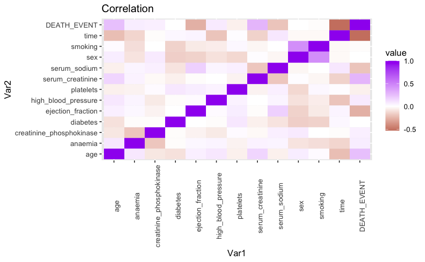

```r
# calculating correlations and rounding to nearest 2 decimal points
cormap <- round( cor(data), 2)

#convert the matrix to a dataframe
cormap_melted<-melt(cormap)


#creating heatmap
ggplot(data = cormap_melted, aes(x=Var1, y=Var2, fill=value) ) +
  geom_tile() + scale_fill_gradient2(low="darkred",high="purple",mid="white") + theme(axis.text.x = element_text(angle = 90)) + labs(title = 'Correlation')
```

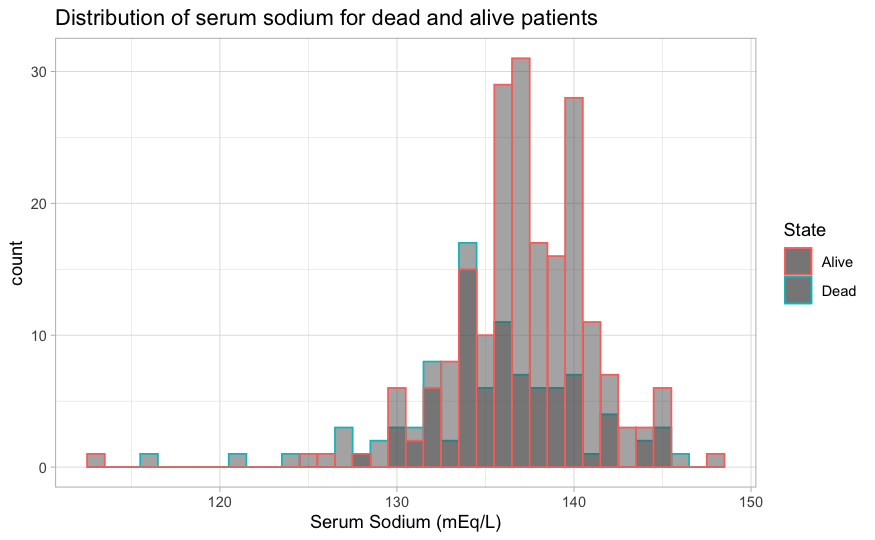

```r
dead_sodium <- filter(data, DEATH_EVENT==1) %>% select(serum_sodium)
alive_sodium <- filter(data, DEATH_EVENT==0) %>% select(serum_sodium)

ggplot() +
  geom_histogram(data = dead_sodium, aes(serum_sodium, color='Dead'), alpha=0.5, binwidth = 1) +
  geom_histogram(data = alive_sodium,aes(serum_sodium, color='Alive'), alpha = 0.5, binwidth = 1) +
  theme_light() + labs(color='State', title='Distribution of serum sodium for dead and alive patients', x='Serum Sodium (mEq/L)')
```

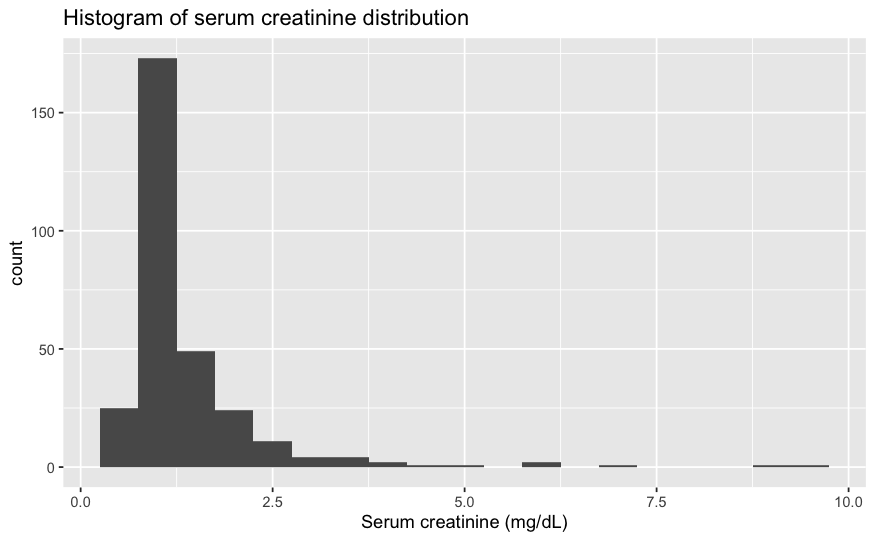

```r
ggplot(data, aes(x = serum_creatinine)) + geom_histogram(binwidth = 0.5) + labs(title='Histogram of serum creatinine distribution', x='Serum creatinine (mg/dL)')
```

##### The distribution of `serum_sodium` is left skewed, while `serum_creatinine` is right skewed.

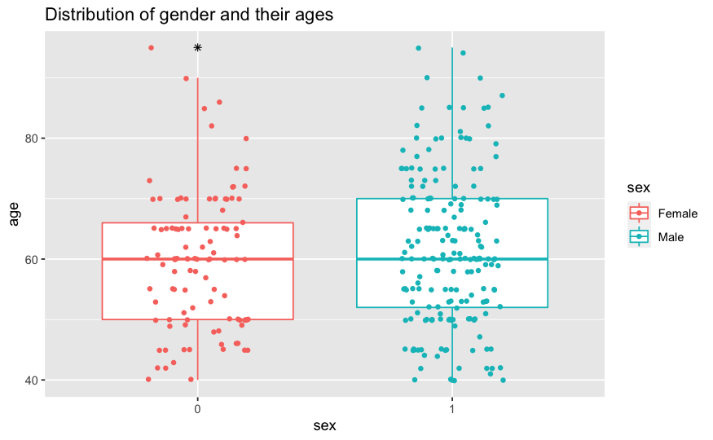

```r
ggplot(data, aes(x=factor(sex), y=age, color=factor(sex))) + geom_boxplot(outlier.color = 'black', outlier.shape = 8) + geom_jitter(shape=16, position=position_jitter(0.2)) + labs(x='sex', title='Distribution of gender and their ages', color='sex') + scale_color_discrete(labels=c('Female', 'Male'))
```

#### Next, lets investigate some relations

### The duration of illness of dead patient and recovered patient

[figure not shown]

```r
#Visualize the density distribution function of duration of illness and death event
 ggplot(data, aes(x = time, fill = as.factor(DEATH_EVENT) )) +
        geom_density(alpha = 0.2) + theme_classic() +
        labs(title = "Density Distribution of Time", fill="Dead", x='Time of illness') + scale_fill_discrete(labels=c("Yes", "No"))
```

### Let’s see ejection fraction affects the occurance of heart failure.

[figure not shown]

```r
#Visualize the density distribution function of smoking and the death event
 ggplot(data,aes(x = ejection_fraction, fill = as.factor(DEATH_EVENT))) +
        geom_density(alpha = 0.2) + theme_classic() +
        labs(title = "Density Distribution of ejection fraction to death events", fill='Dead', x='Ejection Fraction')+ scale_fill_discrete(labels=c("Yes", "No"))
```

### Creating the descision tree

```r
set.seed(123)
data$Dead<-ifelse(data$DEATH_EVENT!=1,"No","Yes")

#This variable is no needed for constructing a classification tree
data$DEATH_EVENT<-NULL

#creating tree, I will use a small critical point
heartTree<-rpart(Dead~.,data=data,control=rpart.control(cp=0.00001))
heartTree
```

```
n= 299

node), split, n, loss, yval, (yprob)
      * denotes terminal node

 1) root 299 96 No (0.67892977 0.32107023)
   2) time>=73.5 223 33 No (0.85201794 0.14798206)
     4) serum_creatinine< 1.55 182 14 No (0.92307692 0.07692308) *
     5) serum_creatinine>=1.55 41 19 No (0.53658537 0.46341463)
      10) time>=210 10  1 No (0.90000000 0.10000000) *
      11) time< 210 31 13 Yes (0.41935484 0.58064516)
        22) platelets>=226000 18  8 No (0.55555556 0.44444444) *
        23) platelets< 226000 13  3 Yes (0.23076923 0.76923077) *
   3) time< 73.5 76 13 Yes (0.17105263 0.82894737)
     6) serum_sodium>=136.5 37 11 Yes (0.29729730 0.70270270)
      12) time>=48.5 12  5 No (0.58333333 0.41666667) *
      13) time< 48.5 25  4 Yes (0.16000000 0.84000000) *
     7) serum_sodium< 136.5 39  2 Yes (0.05128205 0.94871795) *
```

```r
printcp(heartTree)
```

```
Classification tree:
rpart(formula = Dead ~ ., data = data, control = rpart.control(cp = 1e-05))

Variables actually used in tree construction:
[1] platelets        serum_creatinine serum_sodium     time

Root node error: 96/299 = 0.32107

n= 299

        CP nsplit rel error  xerror     xstd
1 0.520833      0   1.00000 1.00000 0.084096
2 0.026042      1   0.47917 0.51042 0.066675
3 0.020833      3   0.42708 0.58333 0.070273
4 0.010417      4   0.40625 0.58333 0.070273
5 0.000010      6   0.38542 0.61458 0.071684
```

```r
#Creating a matrix to check the accuracy of decision tree
conf.matrix <- table(data$Dead, predict(heartTree, type="class"))

rownames(conf.matrix) <- paste("Actual", rownames(conf.matrix), sep = ":")

colnames(conf.matrix) <- paste("Pred", colnames(conf.matrix), sep = ":")

print(conf.matrix)
```

```
             Pred:No Pred:Yes
  Actual:No      194        9
  Actual:Yes      28       68
```

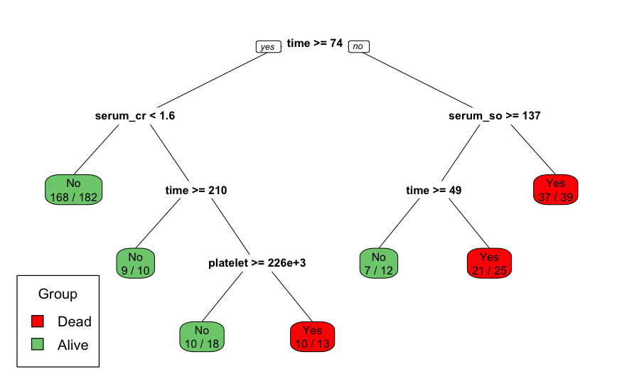

```r
boxcols <- c("palegreen3","red")[heartTree$frame$yval]

par(xpd=TRUE)
prp(heartTree, faclen = 0, cex = 0.8, box.col = boxcols,extra=2)
legend("bottomleft", legend = c("Dead","Alive"), fill = c("red", "palegreen3"),
       title = "Group")
```

```r
Accuracy<-(conf.matrix[1,1] + conf.matrix[2,2])/sum(conf.matrix)*100

Accuracy
```

```
[1] 87.62542
```

### Finding the real impact of features

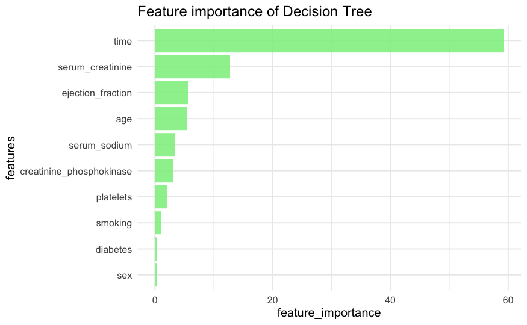

```r
# We will create a bar chart to visualize the feature importance descendingly
importance <- data.frame(variables = names(heartTree$variable.importance), feature_importance = heartTree$variable.importance)

  ggplot(data = importance, aes(x=feature_importance, y=reorder(variables, X= feature_importance))) + geom_bar(stat = "identity",
            fill = 'lightgreen',
             alpha=0.9) +
    labs(y = "features", title = "Feature importance of Decision Tree") +
    theme_minimal(base_size = 12)
```

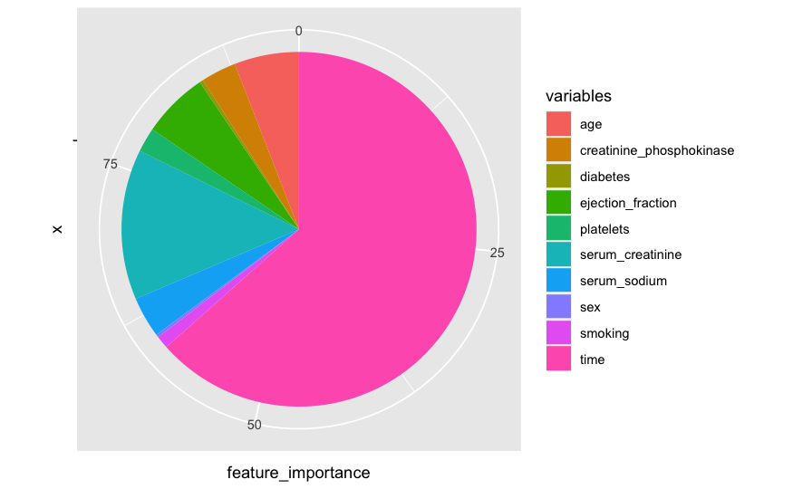

```r
#Visualize the feature importance using pie chart
importance <- data.frame(variables=names(heartTree$variable.importance), feature_importance=heartTree$variable.importance)
ggplot(data=importance, aes(x="", y=feature_importance, fill=variables)) + geom_bar(stat="identity", width=1) +
  coord_polar("y", start=0)
```

#### * `sex` is not as effective as time